# UAV Tradespace Exploration Tutorial

In this tutorial, we will be using the `UAVTradespacer` module to perform tradespace analysis for Unmanned Aerial Vehicles (UAVs). Tradespace analysis is a method used in the early stages of design to explore a wide range of design alternatives and understand the trade-offs between different design decisions.

Let's get started!

```python
from uav_tradespace import UAVTradespacer

%load_ext autoreload
%autoreload 2
```

## Performance Variables or Attributes

Performance variables or Attributes are used to evaluate the performance of a system. In this case, the system is a drone. The rules for selecting the performance variables are:

1. The performance variables must represent how good the system is.
2. They must be measurable.
3. They will be used to compare different designs.

```python
# Define your performance variables
uav_td = UAVTradespacer()

# Add performance variables
# Add maximum flight distance
uav_td.add_performance_variable("max_flight_distance", 4000, 10000, "m", 0.25)

# Add maximum speed
uav_td.add_performance_variable("max_speed", 7, 40, "m/s", 0.10)

# Add maximum payload
uav_td.add_performance_variable("max_payload", 0.2, 3, "kg", 0.25)

# Add maximum endurance
uav_td.add_performance_variable("max_flight_time", 10, 40, "min", 0.35)

# set the desired price range
uav_td.set_desired_price_range(None, 600)
```

## Design Variables

Design variables are the variables that can be changed to improve the performance of the system. In this case, the system is a drone. The rules for selecting the design variables are:

1. The design variables are the components of the drone.
2. Their characteristics must be measurable.
3. The relationship between the design vars and the performance vars in this case is the mathematical model of the drone.

### Add Batteries options

> On the batteries side, it is possible to choose between different options on the market, varying in weight, capacity, voltage and price. The question that we want to solve is: how those characteristics of each battery affect the performance of the drone? To answer that question, lets add the batteries to the design space.

```python
# Add lipo battery with its attributes
# Add Zeee 2S LiPo Battery 7.4V 60C 1500mAh (Pack with 2 in parallel x 2 in series)
# https://amzn.eu/d/0v9NqXT
uav_td.add_battery(name='zeee_1500_2x', Ub=2 * 7.4, Cb=2 * 3000,
            Cmin=2 * 300, Rb=2 * 0.2, mass=4 * 0.176, price=4 * 32.99)
# Add Tattu 2300mAh 11.1V 45C 3S1P (2 batteries in parallel x 2 in series)
# https://amzn.eu/d/3qAMa69
uav_td.add_battery(name='tatoo_2300_2x', Ub=2 * 11.1, Cb=2 * 2300,
            Cmin=2 * 230, Rb=2 * 0.2, mass=4 * 0.1822, price=4 * 26.19)
# Add HRB 2 Pack 3S 11,1 V 5000 mAh LiPo-accu 50 C (2 batteries in series)
# https://amzn.eu/d/bihiQ4N
uav_td.add_battery(name='hrb_5000', Ub=2 * 11.1, Cb=5000,
            Cmin=500, Rb=2 * 0.2, mass=2 * 0.376, price=2 * 45.99)
# Add Zeee 3S Lipo Battery 11.1V 100C 8000mAh
# https://amzn.eu/d/8p7C5QJ
uav_td.add_battery(name='zeee_8000', Ub=11.1, Cb=8000,
            Cmin=800, Rb=0.2, mass=0.493, price=79.99)
# Add Tattu Lipo 6S RC Battery 22.2V 1300mAh 120C (2 batteries in parallel x 2 in series)
# https://amzn.eu/d/fp4bDz7
uav_td.add_battery(name='tatoo_1300_2x', Ub=2 * 22.2, Cb=2 * 1300,
            Cmin= 2 * 130, Rb=2 * 0.2, mass=4 * 0.212, price=4 * 41.62)

# two 5000 in series
uav_td.add_battery(name='4s_5000', Ub=2 * 14.8, Cb=5000,
            Cmin=500, Rb=2 * 0.2, mass=2 * 0.376, price=2 * 45.99)
```

### Motors

```python
# Add motor with its attributes
# Add TMOTOR Velox Victory V3008 1350kv
# https://shop.tmotor.com/products/cinematic-fpv-drone-motor-v3008
uav_td.add_motor(name='motor_v3008', Kv0=1350, Um0=10,
          Im0=1.18, Rm=0.1, mass=0.07, price=28.39)
# Add TMOTOR VELOCE V2808 1950KV
# https://shop.tmotor.com/products/fpv-brushless-motor-v2808?variant=41118111367377
uav_td.add_motor(name='motor_v2808', Kv0=1950, Um0=10,
          Im0=2.45, Rm=0.1, mass=0.061, price=24.83)

# try 2400kv
uav_td.add_motor(name='motor_kv2400', Kv0=2400, Um0=10,
            Im0=2.45, Rm=0.1, mass=0.061, price=24.83)
```

### Propellers

```python
# Add propeller with its attributes
# Add Tmotor MS1101
# https://uav-en.tmotor.com/html/2019/Straight_0429/242.html
# https://store.tmotor.com/goods.php?id=822
uav_td.add_propeller(name='propeller_ms1101', Dp=11, Hp=4.2, Bp=2, mass=0.010, price=13.99 / 2)
# Add Tmotor T9545-A
# https://uav-en.tmotor.com/html/2018/Straight_0416/150.html
# https://store.tmotor.com/goods.php?id=479
uav_td.add_propeller(name='propeller_t9545', Dp=9.5, Hp=4.5, Bp=2, mass=0.008, price=7.99 / 2)
# Add Tmotor MF1302 folding propeller
# https://uav-en.tmotor.com/html/2019/Folding_0603/250.html
# https://store.tmotor.com/goods.php?id=853
uav_td.add_propeller(name='propeller_mf1302', Dp=13, Hp=4.8, Bp=2, mass=0.017, price=29.99 / 2)
```

### ESCs

```python
# Add ESC with its attributes
# Add 30A ESC
uav_td.add_esc(name='esc_30', Re=0.01, mass=0.01, price=10)
# # Add 20A ESC
# add_esc('esc_20', 0.01, 0.01, 10)
```

### Frames

```python
# # Add frame with its attributes
# # Add 450mm frame
# https://www.aliexpress.com/item/1826445939.html?spm=a2g0o.productlist.main.1.50754792nUZ6Lo&algo_pvid=4287122b-6c35-4298-8ae2-759823a1c0b5&algo_exp_id=4287122b-6c35-4298-8ae2-759823a1c0b5-0&pdp_npi=3%40dis%21USD%2132.27%2119.04%21%21%2132.27%21%21%40212249cb16899388764054185d076a%2110000013899219007%21sea%21NL%212631492666&curPageLogUid=LcEeOINnKP5O
uav_td.add_frame(name='frame_450', Df=450, nr=4, mass=0.282, price=17.86)
# # Add custom 3D printed frame
uav_td.add_frame(name='cig_frame', Df=450, nr=6, mass=0.3, price=20)
```

### Onboard Computer

```python
# add_onboard_computer(name='raspberry_pi_4', Icontrol=1, mass=0.046, price=100)
uav_td.add_onboard_computer(name='jetson_nano', Icontrol=3, mass=0.100, price=150)
```

## Generate the Design Space

The design space is the set of all possible designs. In this case, the design space is the set of all possible drones. The system will generate all the possible combinations of the design variables and will evaluate the performance of each design.

```python
# save design components to json file
uav_td.save_components_to_json('design_components.json')

# generate the tradespace
uav_td.generate_tradespace()
```

## Visualize the Design Space

### The MAU and the SAU

For visualization, we want to have the best design score at the lowest cost. The design score in the tradespace exploration theory is called Multi Attribute Utility MAU. The MAU is a weighted mean of the scores for each performance variable, called Single Attribute Utility SAU. The SAU is calculated based on the Mission requirements that were defined in the beginning of the design process. The MAU is calculated as follows:

$$MAU = \sum_{i=1}^{n} w_i SAU_i$$

Where $w_i$ is the weight of the performance variable $i$ and $n$ is the number of performance variables.

### The Pareto Front

The Pareto Front is the set of designs that are not dominated by any other design. A design dominates another design if it has a better MAU and a lower cost. The Pareto Front is the set of designs that are the best in the tradespace. The Pareto Front is calculated by the system and is shown in the visualization.

```python
# see the tradespace
# uav_td.td.plot_tradespace_plotly('price', 'MAU')
uav_td.plot_price_vs_mau()
```

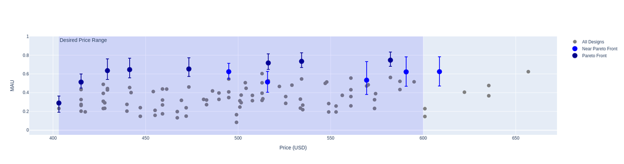

```python
uav_td.plot_price_vs_performances()
```

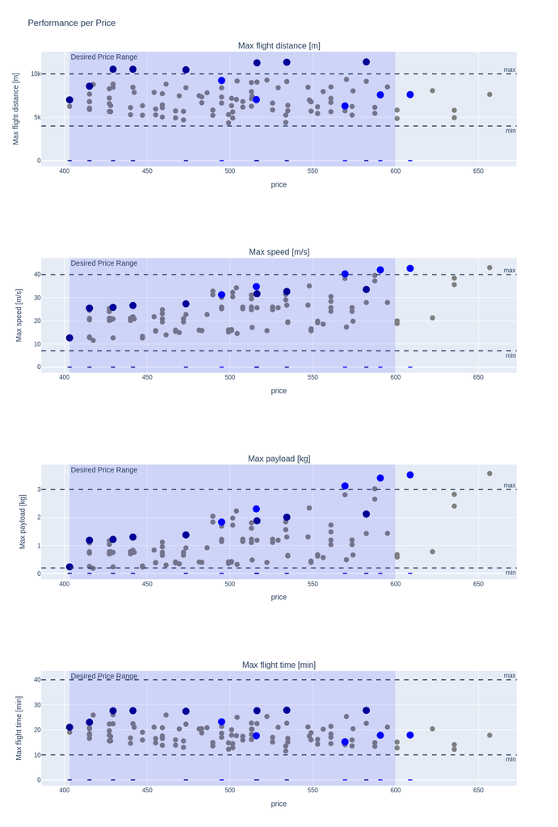

## The Design Space Visualization

```python
uav_td.plot_all_attributes('price', 'mau')
```

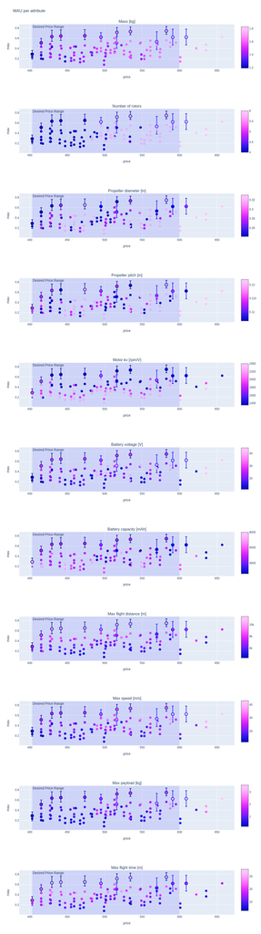

## Choosing the best design

For that, we can get the uav model from the uav_list and call the function uav.show_all() to see all the characteristics of the design, including its performance attributes in different mission scenarios.

```python
uav = uav_td.uav_list[94]
uav.show_all()
```

```
----------------------------------------
        UAV Model Configuration
----------------------------------------
----------------------------------------
            Input parameters
----------------------------------------
              Environment
Temperature:                      25.000 °C
Altitude:                         60.000 m

                General
Mass:                              1.522 Kg

               Propeller
Diameter:                          0.330 m
Pitch:                             0.122 m
Blade number:                      2.000 units

                 Motor
Motor constant:                 1350.000 rpm/V
Motor no-load voltage:            10.000 V
Motor no-load current:             1.180 A
Motor resistance:                  0.100 Ohm
Number of rotors:                  4.000 units

                  ESC
Equivalent resistance:             0.010 Ohm

                Battery
Battery voltage:                  29.600 V
Battery capacity:               5000.000 mAh
Minimum battery capacity:        500.000 mAh
Battery internal resistance:       0.400 Ohm

                 Others
Control current:                   3.000 A
Max duty for max payload:          0.700 %

----------------------------------------
         Calculated parameters
```

[output cut: 49 more lines]

```
Motor current:                   119.383 A
Duty cycle:                        0.700 %
ESC voltage:                      -3.827 V
ESC current:                      83.568 A
Battery current:                 337.272 A
Flight time:                       0.801 min
Efficiency:                        0.359
Maximum payload:                   1.379 Kg
Maximum pitch:                    84.194 deg

              Reachability
----------------------------------------
Maximum distance:              10467.706 m
Maximum speed:                    27.344 m/s
----------------------------------------
```

### Thank you! We hope you enjoyed this tutorial and learned something about the design of drones.